# Word Learning

Kimberly A. Brink

September 13, 2017

“Word Learning” is a study that assesses whether children will selectively trust a robot that provides accurate information compared to a robot that provides inaccurate information. Children watch two robots name a series of familiar objects, where one robot always names the object correctly and the other robot always incorrectly names the robot. The two robots are distingushed by their colors.

There were 6 no shows. There were 0 cancelled appointments There were 0 fuss outs. There were 4 children that did not assent.

## Demographics

There are 41 participants.

The average age of the sample is 41.45 months.

The median age of the sample is 41.67 months.

The minimum age of the sample is 36.1 months.

The maximum age of the sample is 48 months.

There are 19 females in the sample.

The first date of test was 2017-03-21.

The most recent date of test was 2017-09-13.

Age(months)

| Min. | 1st Qu. | Median | Mean | 3rd Qu. | Max. |
| --- | --- | --- | --- | --- | --- |
| 36.1 | 37.5 | 41.67 | 41.45 | 44.87 | 48 |

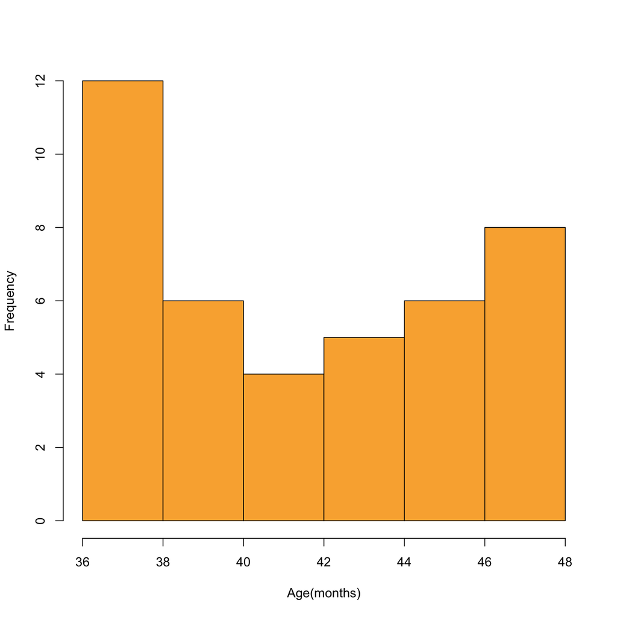

Age(years)

| Min. | 1st Qu. | Median | Mean | 3rd Qu. | Max. |
| --- | --- | --- | --- | --- | --- |
| 3.008 | 3.125 | 3.472 | 3.455 | 3.739 | 4 |

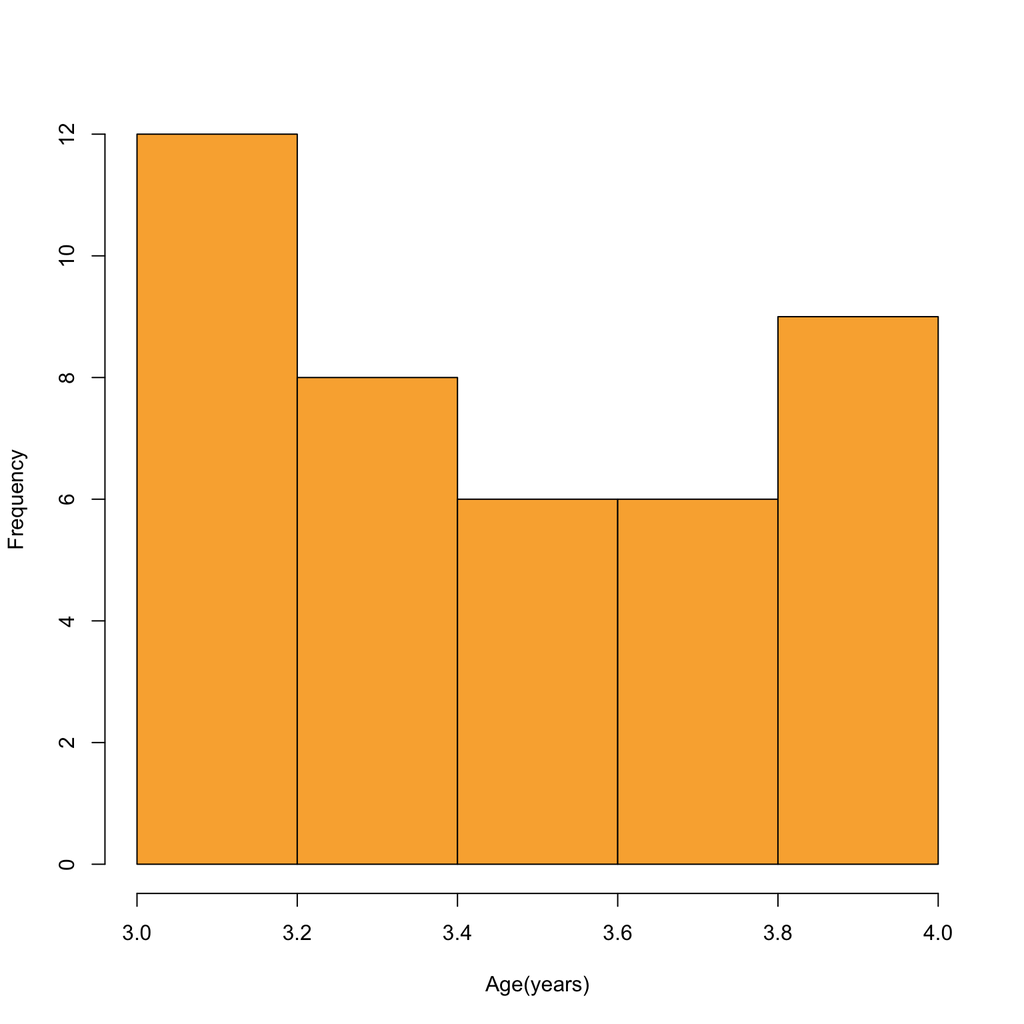

Distribution by Order of Presentation

| A | B | C | D |
| --- | --- | --- | --- |
| 11 | 11 | 9 | 10 |

## Performance during accuracy trials

| Min. | 1st Qu. | Median | Mean | 3rd Qu. | Max. |
| --- | --- | --- | --- | --- | --- |
| 1 | 3 | 4 | 3.463 | 4 | 4 |

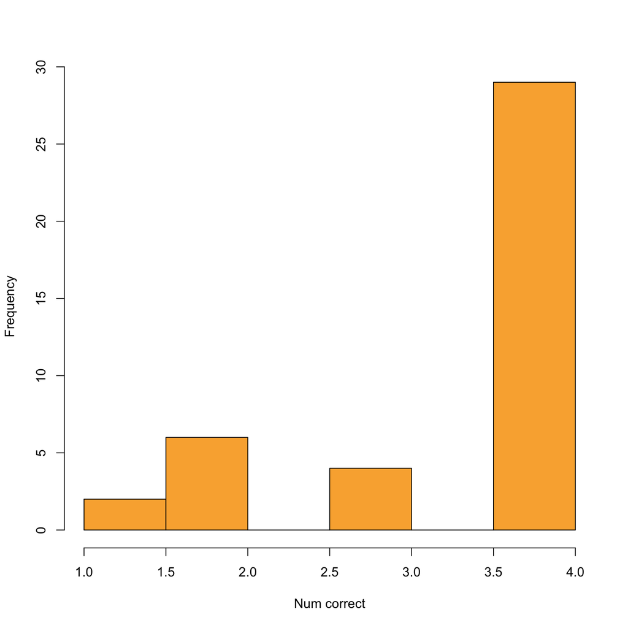

Participant Count by Number of Trials Correct

| 1 | 2 | 3 | 4 |
| --- | --- | --- | --- |
| 2 | 6 | 4 | 29 |

Distribution by Order of Presentation after removing for familiarization

| A | B | C | D |
| --- | --- | --- | --- |
| 8 | 7 | 6 | 8 |

Now there are 29 participants after removing for familiarization errors.

There are 29 participants.

The average age of the sample is 41.42 months.

The median age of the sample is 41.83 months.

The minimum age of the sample is 36.1 months.

The maximum age of the sample is 47.83 months.

There are 15 females in the sample.

The first date of test was 2017-03-21.

The most recent date of test was 2017-09-13.

Analysis of Variance Model

|  | Df | Sum Sq | Mean Sq | F value | Pr(>F) |
| --- | --- | --- | --- | --- | --- |
| **Order** | 3 | 0.07261 | 0.0242 | 0.8221 | 0.494 |
| **Residuals** | 25 | 0.736 | 0.02944 | NA | NA |

|  | Estimate | Std. Error | t value | Pr(>\|t\|) |
| --- | --- | --- | --- | --- |
| **OrderB** | -0.1372 | 0.09015 | -1.522 | 0.1411 |
| **OrderC** | -0.008688 | 0.09258 | -0.09385 | 0.926 |
| **OrderD** | -0.006472 | 0.08584 | -0.07539 | 0.9405 |
| **Age** | 0.008351 | 0.007967 | 1.048 | 0.305 |
| **(Intercept)** | 0.1675 | 0.3308 | 0.5063 | 0.6173 |

(Dispersion parameter for gaussian family taken to be 0.02932 )

| Null deviance: | 0.8086 on 28 degrees of freedom |
| --- | --- |
| Residual deviance: | 0.7038 on 24 degrees of freedom |

|  | Estimate | Std. Error | t value | Pr(>\|t\|) |
| --- | --- | --- | --- | --- |
| **OrderB** | -0.1052 | 0.1108 | -0.949 | 0.3545 |
| **OrderC** | -0.02688 | 0.1064 | -0.2527 | 0.8032 |
| **OrderD** | -0.04283 | 0.1127 | -0.38 | 0.7081 |
| **AgIndex** | -0.003393 | 0.04646 | -0.07302 | 0.9426 |
| **(Intercept)** | 0.5283 | 0.09386 | 5.629 | 0.00001992 |

(Dispersion parameter for gaussian family taken to be 0.03481 )

| Null deviance: | 0.6941 on 23 degrees of freedom |
| --- | --- |
| Residual deviance: | 0.6614 on 19 degrees of freedom |

Total Correct Breakdown

| Min. | 1st Qu. | Median | Mean | 3rd Qu. | Max. |
| --- | --- | --- | --- | --- | --- |
| 0.2 | 0.3 | 0.5 | 0.4767 | 0.6 | 0.8 |

*0.1699*

# Comparisons with chance for three test questions.

Proportion of Explicit Judgment Questions Correct

| Min. | 1st Qu. | Median | Mean | 3rd Qu. | Max. |
| --- | --- | --- | --- | --- | --- |
| 0 | 0 | 0.5 | 0.5862 | 1 | 1 |

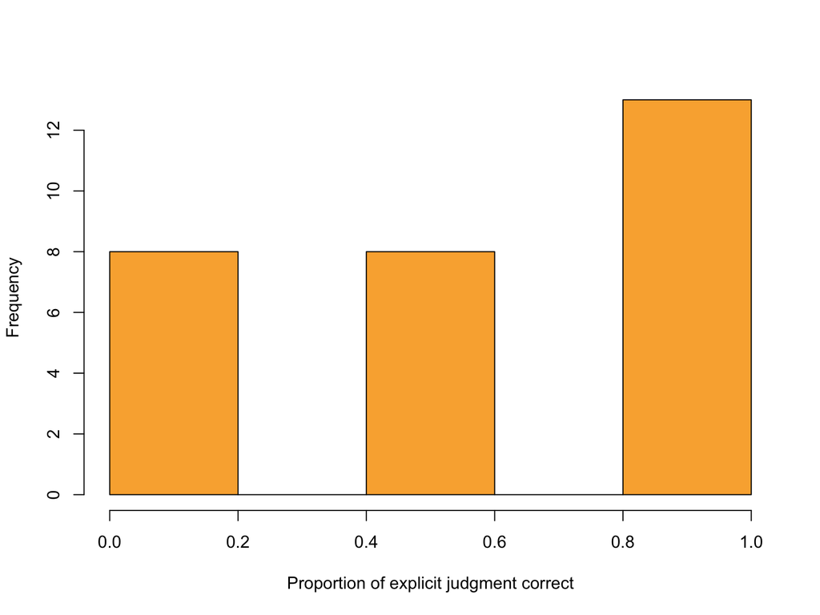

Proportion of Ask Questions correct

| Min. | 1st Qu. | Median | Mean | 3rd Qu. | Max. |
| --- | --- | --- | --- | --- | --- |
| 0 | 0.25 | 0.5 | 0.5029 | 0.75 | 1 |

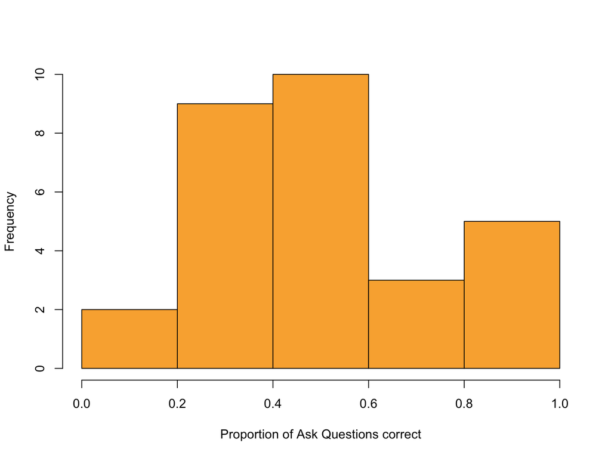

Proportion of Endorsement Questions correct

| Min. | 1st Qu. | Median | Mean | 3rd Qu. | Max. |
| --- | --- | --- | --- | --- | --- |
| 0 | 0.25 | 0.5 | 0.5057 | 0.75 | 1 |

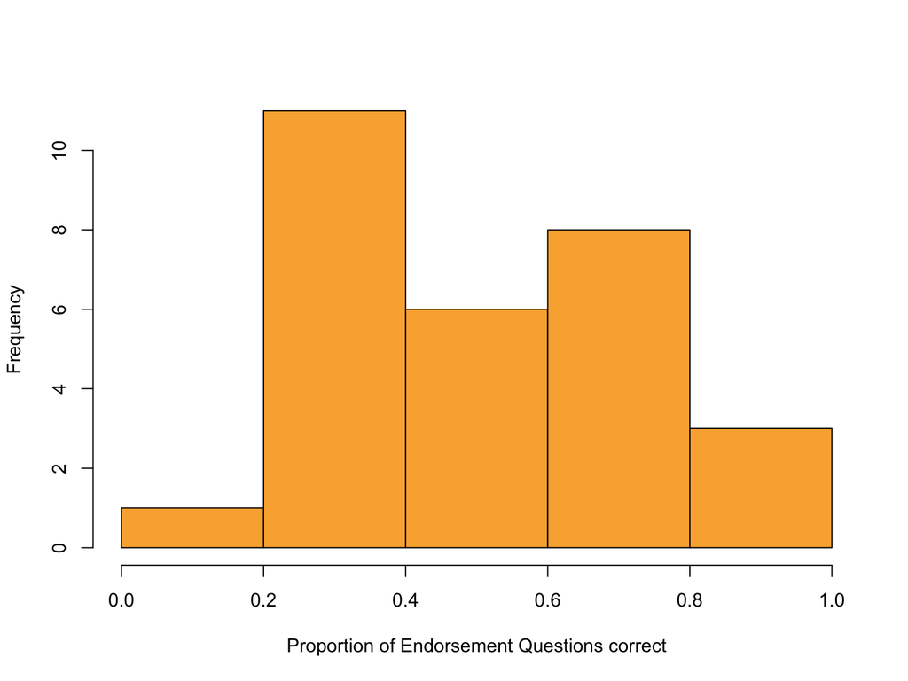

Performance across all questions

| Min. | 1st Qu. | Median | Mean | 3rd Qu. | Max. |
| --- | --- | --- | --- | --- | --- |
| 0.2 | 0.3 | 0.5 | 0.4767 | 0.6 | 0.8 |

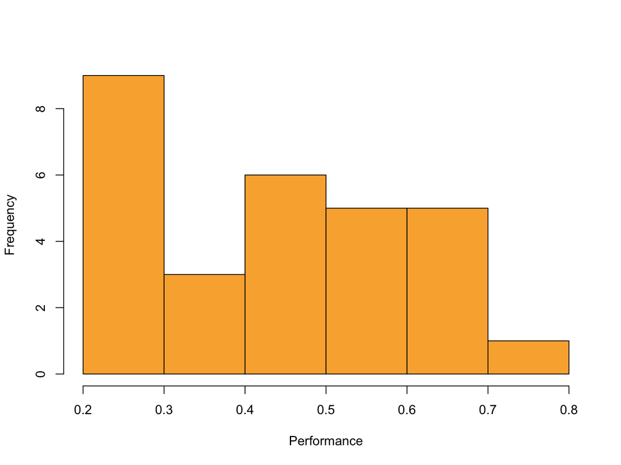

| Question | Proportion | t.df. | X95.CI |
| --- | --- | --- | --- |
| Explicit judgment | 0.59(0.08) | 1.09(28) | 0.42,0.75 |
| Ask | 0.5(0.06) | 0.05(28) | 0.39,0.62 |
| Endorse | 0.51(0.05) | 0.11(28) | 0.4,0.61 |

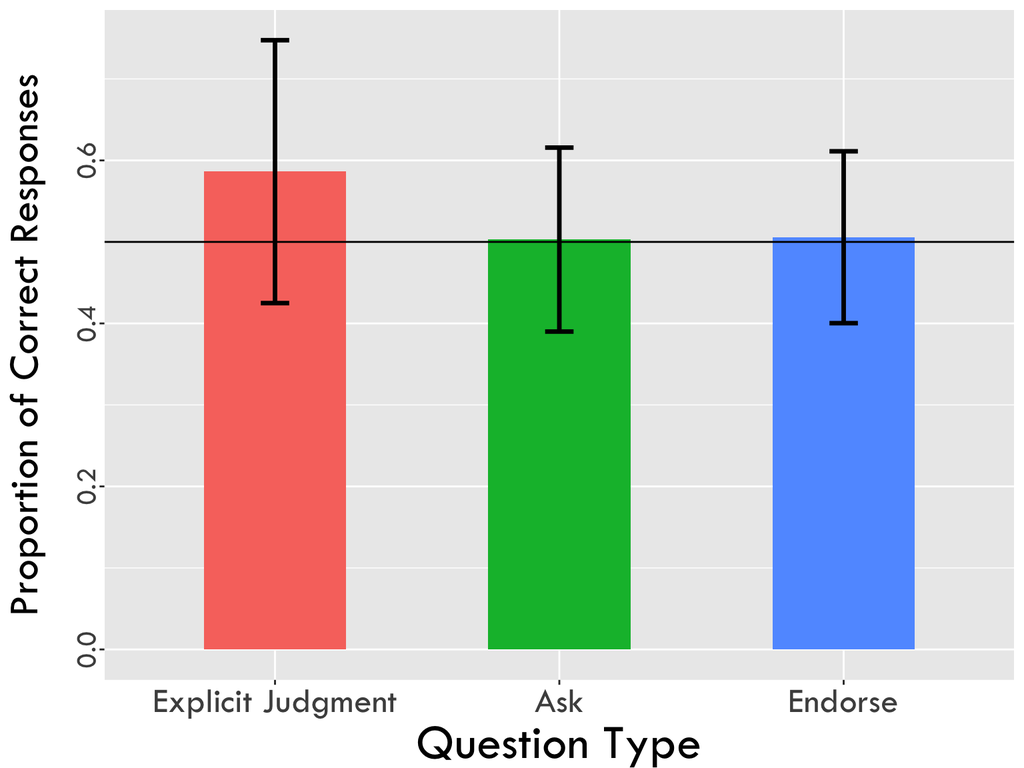

```
##
##  One Sample t-test
##
## data:  WL2$EJ.Purple
## t = -1.1, df = 28, p-value = 0.3
## alternative hypothesis: true mean is not equal to 0.5
## 95 percent confidence interval:
##  0.2525 0.5751
## sample estimates:
## mean of x
##    0.4138
```

```
##
##  One Sample t-test
##
## data:  WL2$Ask.Purple
## t = -0.37, df = 28, p-value = 0.7
## alternative hypothesis: true mean is not equal to 0.5
## 95 percent confidence interval:
##  0.3673 0.5925
## sample estimates:
## mean of x
##    0.4799
```

```
##
##  One Sample t-test
##
## data:  WL2$Word.Purple
## t = 1.9, df = 28, p-value = 0.07
## alternative hypothesis: true mean is not equal to 0.5
## 95 percent confidence interval:
##  0.4927 0.6912
## sample estimates:
## mean of x
##     0.592
```

```
##
##  One Sample t-test
##
## data:  WL2$EJ.Orange
## t = 1.1, df = 28, p-value = 0.3
## alternative hypothesis: true mean is not equal to 0.5
## 95 percent confidence interval:
##  0.4249 0.7475
## sample estimates:
## mean of x
##    0.5862
```

```
##
##  One Sample t-test
##
## data:  WL2$Ask.Orange
## t = 0.37, df = 28, p-value = 0.7
## alternative hypothesis: true mean is not equal to 0.5
## 95 percent confidence interval:
##  0.4075 0.6327
## sample estimates:
## mean of x
##    0.5201
```

```
##
##  One Sample t-test
##
## data:  WL2$Word.Orange
## t = -1.9, df = 28, p-value = 0.07
## alternative hypothesis: true mean is not equal to 0.5
## 95 percent confidence interval:
##  0.3088 0.5073
## sample estimates:
## mean of x
##     0.408
```

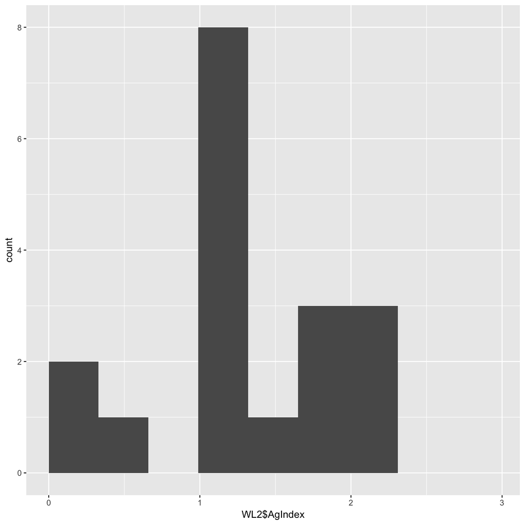

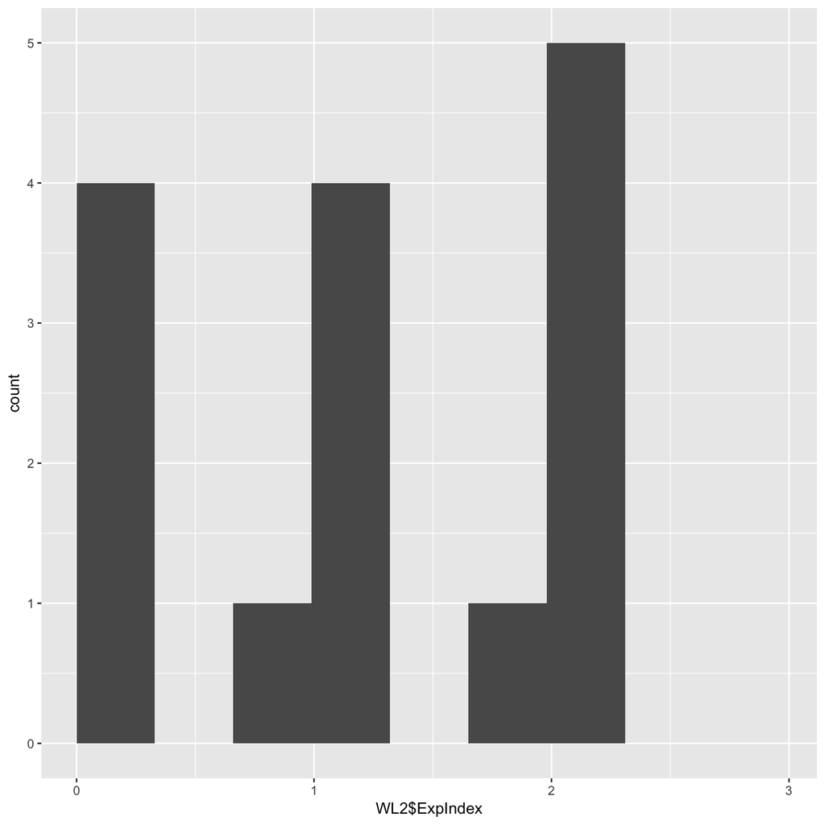

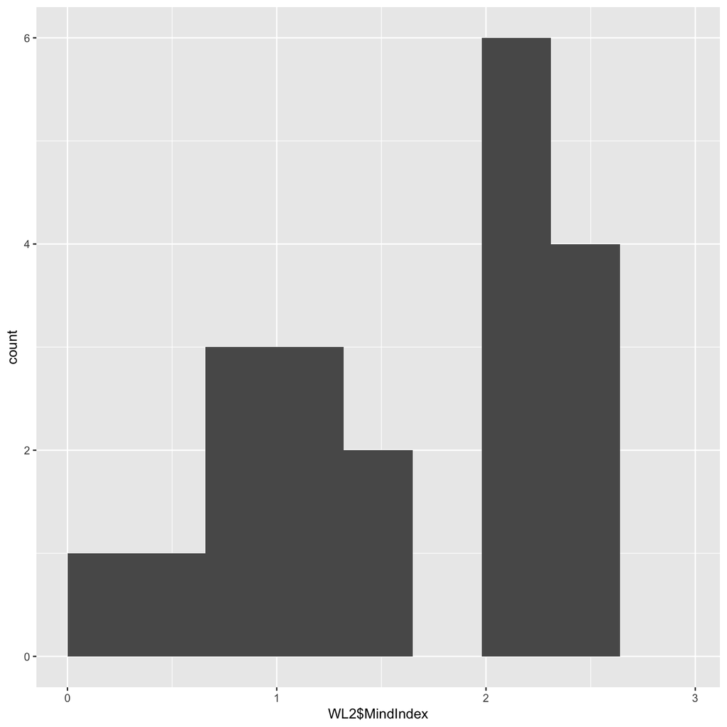

```
##
##  Pearson's product-moment correlation
##
## data:  WL2$AgIndex and WL2$ExpIndex
## t = 2, df = 21, p-value = 0.06
## alternative hypothesis: true correlation is not equal to 0
## 95 percent confidence interval:
##  -0.0238  0.6925
## sample estimates:
##    cor
## 0.3922
```

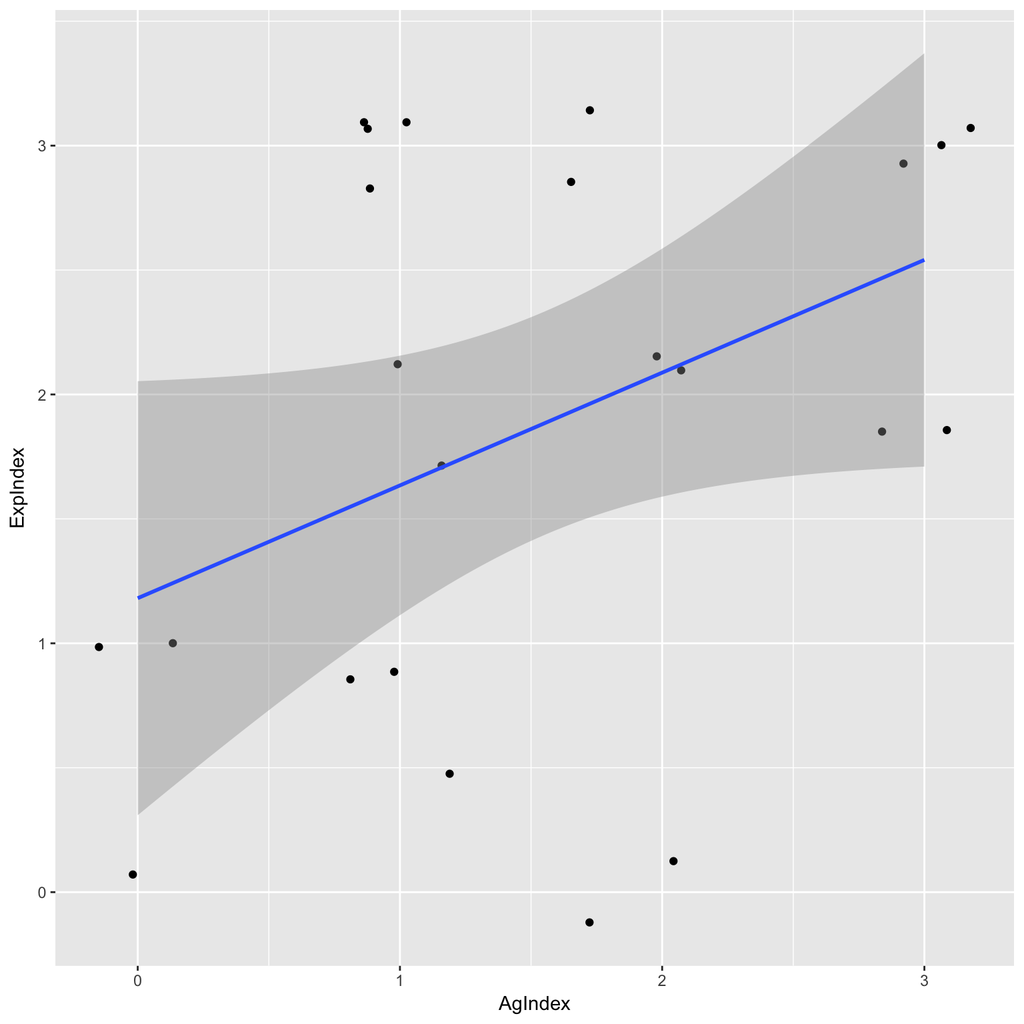

```
##
##  Pearson's product-moment correlation
##
## data:  WL2$Age and WL2$ExpIndex
## t = -1.8, df = 22, p-value = 0.08
## alternative hypothesis: true correlation is not equal to 0
## 95 percent confidence interval:
##  -0.66786  0.04848
## sample estimates:
##    cor
## -0.362
```

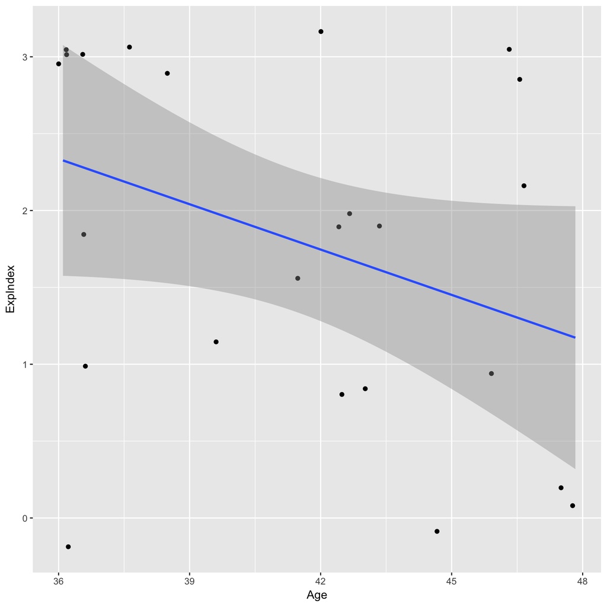

```
##
##  Pearson's product-moment correlation
##
## data:  WL2$Ask.Match and WL2$ExpIndex
## t = -1.1, df = 22, p-value = 0.3
## alternative hypothesis: true correlation is not equal to 0
## 95 percent confidence interval:
##  -0.5767  0.1953
## sample estimates:
##     cor
## -0.2259
```

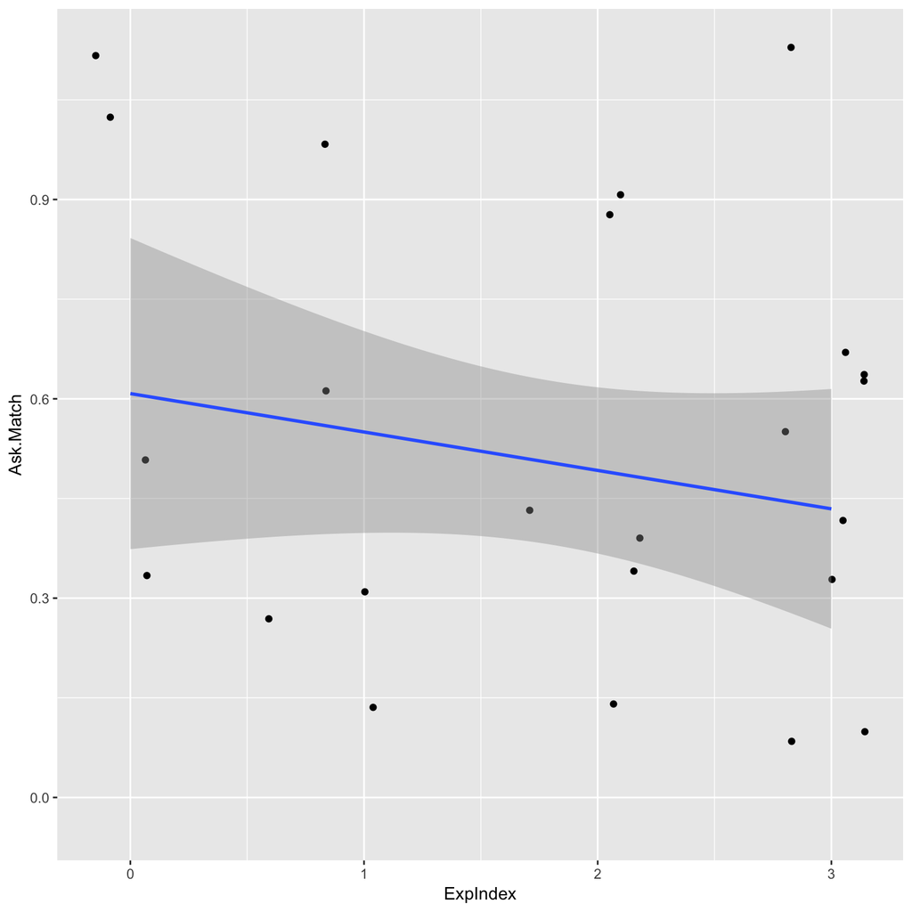

```
##
##  Pearson's product-moment correlation
##
## data:  WL2$Word.Match and WL2$ExpIndex
## t = -1.3, df = 22, p-value = 0.2
## alternative hypothesis: true correlation is not equal to 0
## 95 percent confidence interval:
##  -0.6066  0.1508
## sample estimates:
##    cor
## -0.269
```

[figure not shown]

```
##
##  Pearson's product-moment correlation
##
## data:  WL2$Age and WL2$AgIndex
## t = -1.6, df = 22, p-value = 0.1
## alternative hypothesis: true correlation is not equal to 0
## 95 percent confidence interval:
##  -0.64812  0.08316
## sample estimates:
##     cor
## -0.3314
```

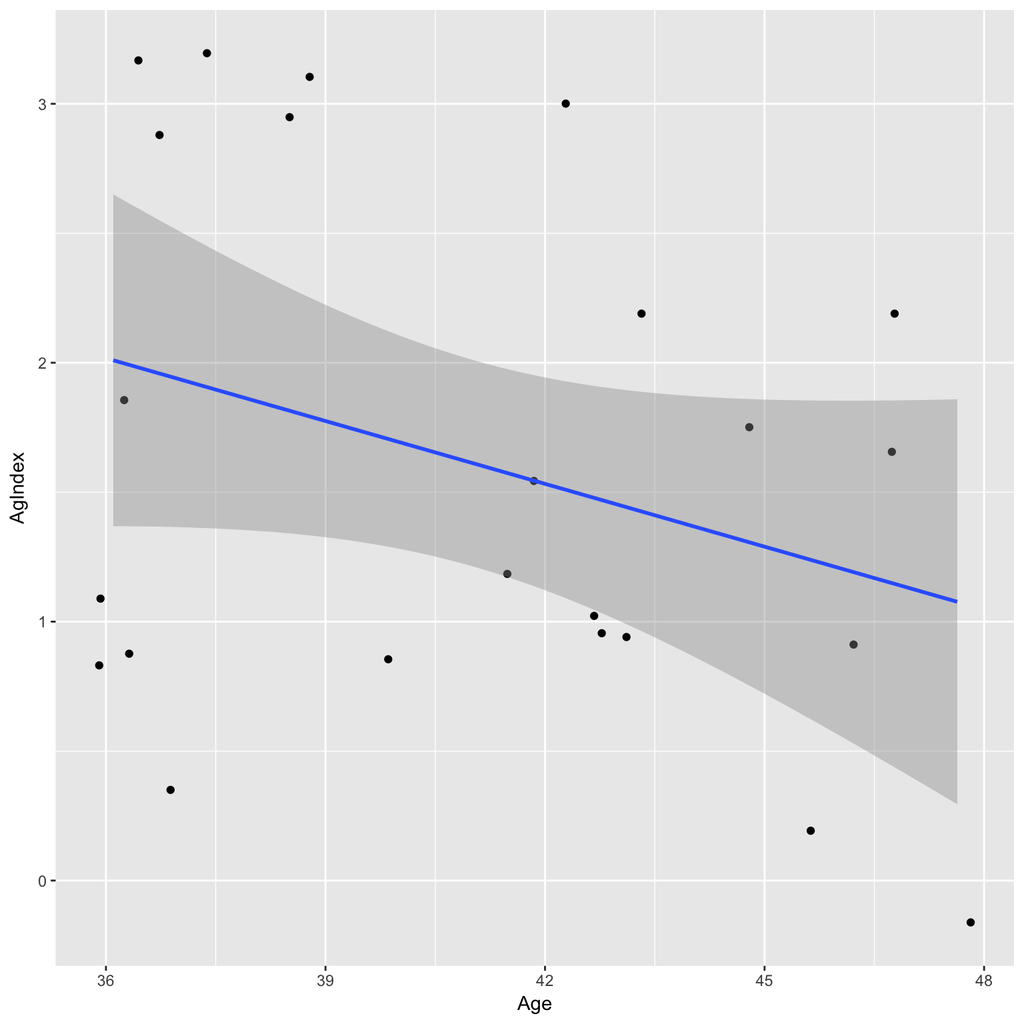

```
##
##  Pearson's product-moment correlation
##
## data:  WL2$Ask.Match and WL2$AgIndex
## t = 0.32, df = 22, p-value = 0.8
## alternative hypothesis: true correlation is not equal to 0
## 95 percent confidence interval:
##  -0.3445  0.4591
## sample estimates:
##     cor
## 0.06842
```

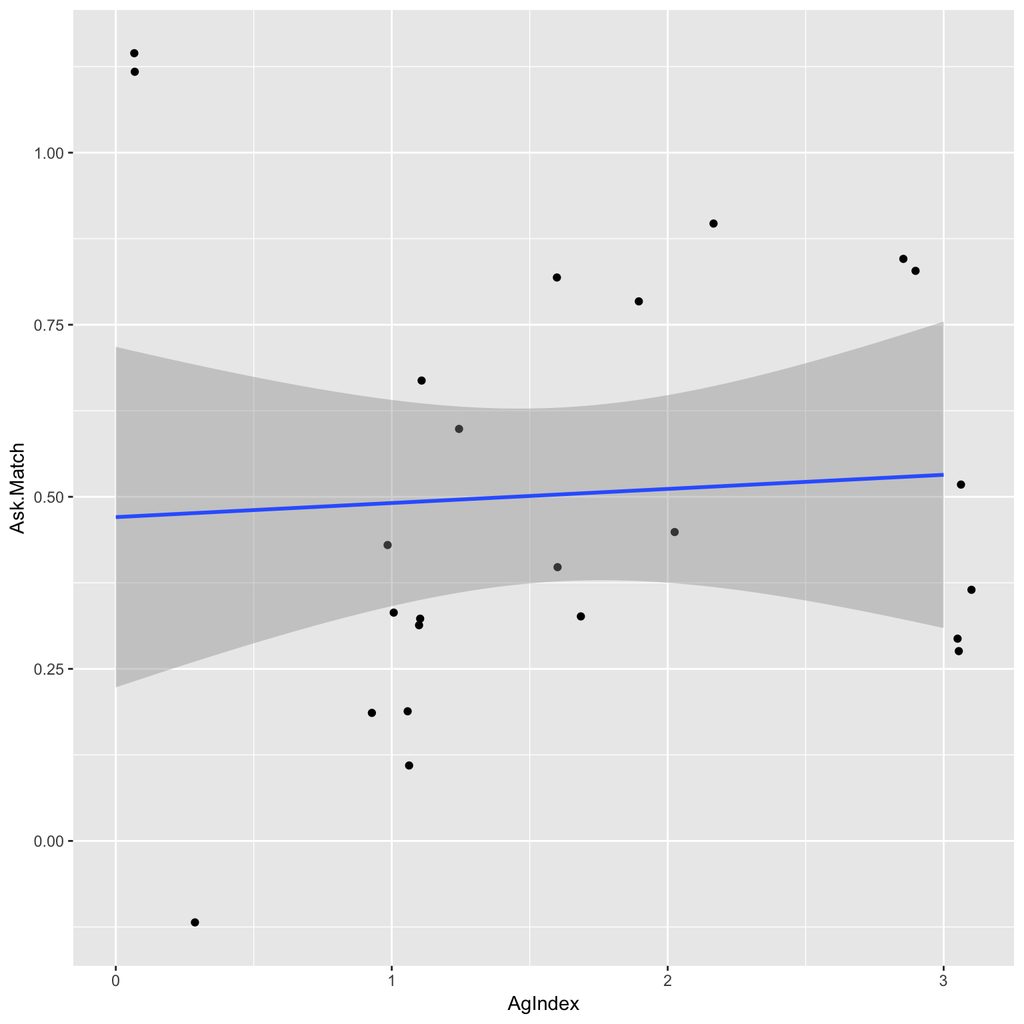

```
##
##  Pearson's product-moment correlation
##
## data:  WL2$Word.Match and WL2$AgIndex
## t = -0.96, df = 22, p-value = 0.3
## alternative hypothesis: true correlation is not equal to 0
## 95 percent confidence interval:
##  -0.5584  0.2212
## sample estimates:
##  cor
## -0.2
```

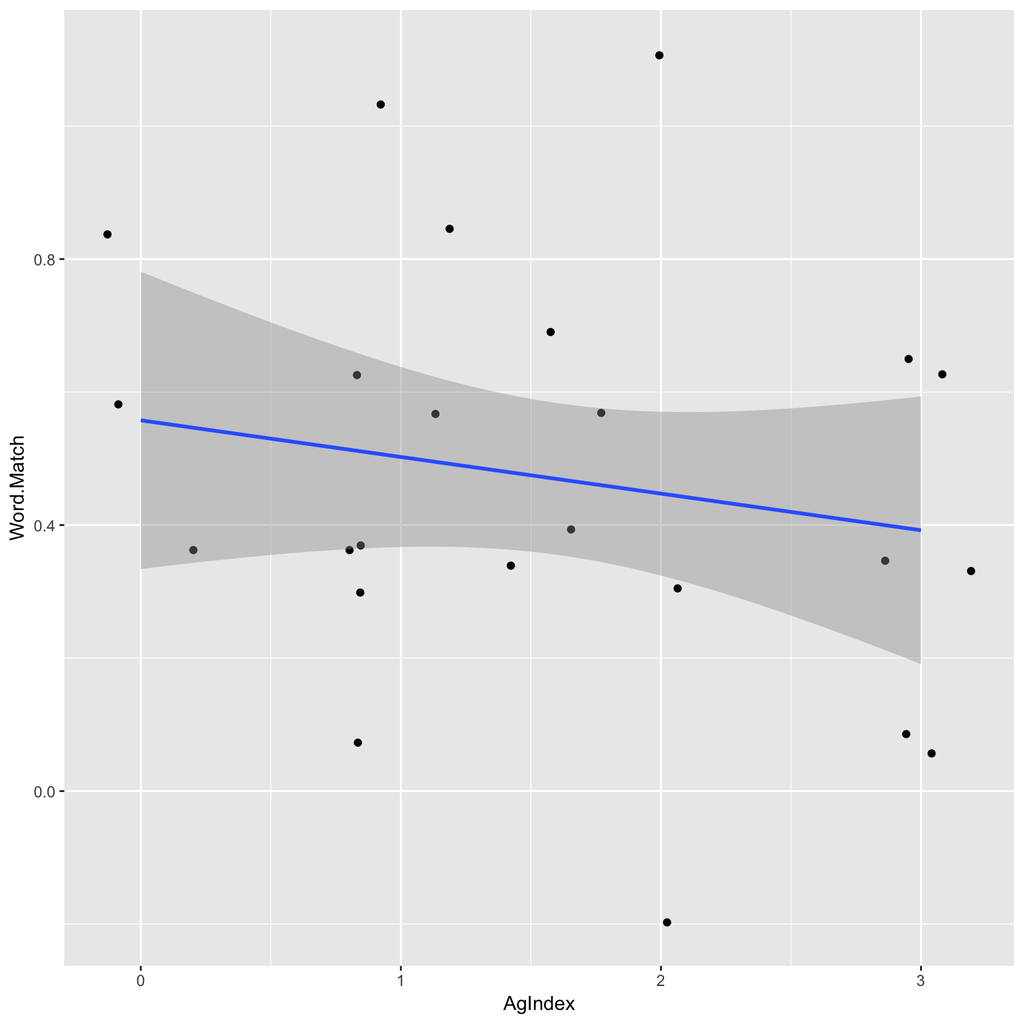

# Predicting Total Correct

```
##
##  Pearson's product-moment correlation
##
## data:  WL2$Total and WL2$AgIndex
## t = 0.09, df = 22, p-value = 0.9
## alternative hypothesis: true correlation is not equal to 0
## 95 percent confidence interval:
##  -0.3872  0.4193
## sample estimates:
##     cor
## 0.01919
```

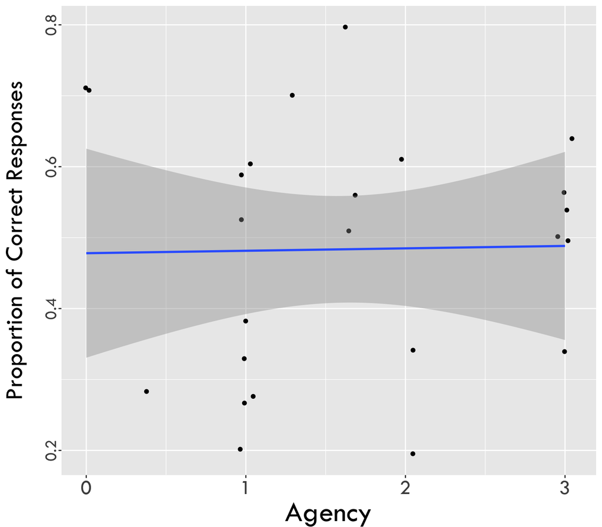

```
##
##  Pearson's product-moment correlation
##
## data:  WL2$Total and WL2$ExpIndex
## t = 0.17, df = 22, p-value = 0.9
## alternative hypothesis: true correlation is not equal to 0
## 95 percent confidence interval:
##  -0.3727  0.4332
## sample estimates:
##     cor
## 0.03614
```

[figure not shown]

## Regression Analyses

```
##
## Call:
## glm(formula = Total ~ ExpIndex.cent + AgIndex.cent, data = WL2)
##
## Deviance Residuals:
##     Min       1Q   Median       3Q      Max
## -0.2846  -0.1814   0.0172   0.1181   0.3163
##
## Coefficients:
##                Estimate Std. Error t value      Pr(>|t|)
## (Intercept)    0.482948   0.040420   11.95 0.00000000015 ***
## ExpIndex.cent -0.000342   0.042986   -0.01          0.99
## AgIndex.cent   0.002565   0.043054    0.06          0.95
## ---
## Signif. codes:  0 '***' 0.001 '**' 0.01 '*' 0.05 '.' 0.1 ' ' 1
##
## (Dispersion parameter for gaussian family taken to be 0.03469)
##
##     Null deviance: 0.69387  on 22  degrees of freedom
## Residual deviance: 0.69373  on 20  degrees of freedom
##   (6 observations deleted due to missingness)
## AIC: -7.256
##
## Number of Fisher Scoring iterations: 2
```

```
## ExpIndex.cent  AgIndex.cent
##     -0.001935      0.014480
```

```
##
## Call:
## glm(formula = Total ~ ExpIndex.cent + AgIndex.cent + Age.cent,
##     data = WL2)
##
## Deviance Residuals:
##     Min       1Q   Median       3Q      Max
## -0.3478  -0.1490   0.0305   0.1303   0.2864
##
## Coefficients:
##               Estimate Std. Error t value Pr(>|t|)
## (Intercept)    0.65440    0.14714    4.45  0.00028 ***
## ExpIndex.cent  0.00925    0.04323    0.21  0.83285
## AgIndex.cent   0.01476    0.04374    0.34  0.73951
## Age.cent       0.69682    0.57553    1.21  0.24084
## ---
## Signif. codes:  0 '***' 0.001 '**' 0.01 '*' 0.05 '.' 0.1 ' ' 1
##
## (Dispersion parameter for gaussian family taken to be 0.0339)
##
##     Null deviance: 0.69387  on 22  degrees of freedom
## Residual deviance: 0.64404  on 19  degrees of freedom
##   (6 observations deleted due to missingness)
## AIC: -6.965
##
## Number of Fisher Scoring iterations: 2
```

```
##
## Call:
## glm(formula = Total ~ ExpIndex.cent + AgIndex.cent + Age.cent +
##     Sex, data = WL2)
##
## Deviance Residuals:
##     Min       1Q   Median       3Q      Max
## -0.3459  -0.1513   0.0321   0.1329   0.2856
##
## Coefficients:
##               Estimate Std. Error t value Pr(>|t|)
## (Intercept)    0.65494    0.15150    4.32  0.00041 ***
## ExpIndex.cent  0.00986    0.04586    0.21  0.83227
## AgIndex.cent   0.01445    0.04530    0.32  0.75337
## Age.cent       0.69028    0.60400    1.14  0.26808
## SexMale       -0.00445    0.08415   -0.05  0.95838
## ---
## Signif. codes:  0 '***' 0.001 '**' 0.01 '*' 0.05 '.' 0.1 ' ' 1
##
## (Dispersion parameter for gaussian family taken to be 0.03577)
##
##     Null deviance: 0.69387  on 22  degrees of freedom
## Residual deviance: 0.64394  on 18  degrees of freedom
##   (6 observations deleted due to missingness)
## AIC: -4.969
##
## Number of Fisher Scoring iterations: 2
```

```
##
## Call:
## glm(formula = Total ~ ExpIndex.cent + AgIndex.cent + Age.cent +
##     Sex + Order, data = WL2)
##
## Deviance Residuals:
##     Min       1Q   Median       3Q      Max
## -0.3261  -0.0914  -0.0029   0.1090   0.2512
##
## Coefficients:
##               Estimate Std. Error t value Pr(>|t|)
## (Intercept)    0.81555    0.19715    4.14  0.00088 ***
## ExpIndex.cent  0.03175    0.05923    0.54  0.59986
## AgIndex.cent   0.00794    0.05469    0.15  0.88652
## Age.cent       0.98212    0.64944    1.51  0.15125
## SexMale       -0.05646    0.09862   -0.57  0.57544
## OrderB        -0.16394    0.12129   -1.35  0.19652
## OrderC        -0.01275    0.13013   -0.10  0.92324
## OrderD        -0.12620    0.13411   -0.94  0.36161
## ---
## Signif. codes:  0 '***' 0.001 '**' 0.01 '*' 0.05 '.' 0.1 ' ' 1
##
## (Dispersion parameter for gaussian family taken to be 0.03736)
##
##     Null deviance: 0.69387  on 22  degrees of freedom
## Residual deviance: 0.56036  on 15  degrees of freedom
##   (6 observations deleted due to missingness)
## AIC: -2.166
##
## Number of Fisher Scoring iterations: 2
```

|  | Estimate | Std. Error | t value | Pr(>\|t\|) |
| --- | --- | --- | --- | --- |
| **ExpIndex.cent** | 0.03175 | 0.05923 | 0.5359 | 0.5999 |
| **AgIndex.cent** | 0.00794 | 0.05469 | 0.1452 | 0.8865 |
| **Age.cent** | 0.9821 | 0.6494 | 1.512 | 0.1512 |
| **SexMale** | -0.05646 | 0.09862 | -0.5725 | 0.5754 |
| **OrderB** | -0.1639 | 0.1213 | -1.352 | 0.1965 |
| **OrderC** | -0.01275 | 0.1301 | -0.09798 | 0.9232 |
| **OrderD** | -0.1262 | 0.1341 | -0.941 | 0.3616 |
| **(Intercept)** | 0.8155 | 0.1972 | 4.137 | 0.0008786 |

Fitting linear model: Total ~ ExpIndex.cent + AgIndex.cent + Age.cent + Sex + Order

| Observations | Residual Std. Error | $R^2$ | Adjusted $R^2$ |
| --- | --- | --- | --- |
| 23 | 0.1933 | 0.1924 | -0.1845 |

```
## ExpIndex.cent  AgIndex.cent      Age.cent       SexMale        OrderB
##       0.17950       0.04482       0.40414      -0.16238            NA
##        OrderC        OrderD
##      -0.07209      -0.71248
```

```
##
## Call:
## glm(formula = Total ~ AgIndex.cent + Age.cent, data = WL2)
##
## Deviance Residuals:
##     Min       1Q   Median       3Q      Max
## -0.3345  -0.1557   0.0229   0.1237   0.2709
##
## Coefficients:
##              Estimate Std. Error t value Pr(>|t|)
## (Intercept)    0.6517     0.1393    4.68  0.00013 ***
## AgIndex.cent   0.0188     0.0377    0.50  0.62209
## Age.cent       0.6737     0.5389    1.25  0.22499
## ---
## Signif. codes:  0 '***' 0.001 '**' 0.01 '*' 0.05 '.' 0.1 ' ' 1
##
## (Dispersion parameter for gaussian family taken to be 0.03075)
##
##     Null deviance: 0.69415  on 23  degrees of freedom
## Residual deviance: 0.64583  on 21  degrees of freedom
##   (5 observations deleted due to missingness)
## AIC: -10.66
##
## Number of Fisher Scoring iterations: 2
```

```
##
## Call:
## glm(formula = Total.bin ~ ExpIndex.cent + AgIndex.cent + Age.cent +
##     Sex, family = "binomial", data = WL2)
##
## Deviance Residuals:
##    Min      1Q  Median      3Q     Max
## -1.334  -1.039  -0.804   1.125   1.623
##
## Coefficients:
##               Estimate Std. Error z value Pr(>|z|)
## (Intercept)     1.5155     1.6725    0.91     0.36
## ExpIndex.cent  -0.0885     0.5083   -0.17     0.86
## AgIndex.cent    0.0337     0.5065    0.07     0.95
## Age.cent        7.4052     6.7582    1.10     0.27
## SexMale         0.1419     0.9292    0.15     0.88
##
## (Dispersion parameter for binomial family taken to be 1)
##
##     Null deviance: 31.492  on 22  degrees of freedom
## Residual deviance: 29.970  on 18  degrees of freedom
##   (6 observations deleted due to missingness)
## AIC: 39.97
##
## Number of Fisher Scoring iterations: 4
```

```
##
## Call:
## glm(formula = Total ~ MindIndex.cent, data = WL2)
##
## Deviance Residuals:
##     Min       1Q   Median       3Q      Max
## -0.2834  -0.1812   0.0159   0.1166   0.3190
##
## Coefficients:
##                Estimate Std. Error t value       Pr(>|t|)
## (Intercept)     0.48253    0.03842   12.56 0.000000000031 ***
## MindIndex.cent  0.00181    0.03944    0.05           0.96
## ---
## Signif. codes:  0 '***' 0.001 '**' 0.01 '*' 0.05 '.' 0.1 ' ' 1
##
## (Dispersion parameter for gaussian family taken to be 0.03304)
##
##     Null deviance: 0.69387  on 22  degrees of freedom
## Residual deviance: 0.69380  on 21  degrees of freedom
##   (6 observations deleted due to missingness)
## AIC: -9.253
##
## Number of Fisher Scoring iterations: 2
```

```
##
## Call:
## glm(formula = Total ~ MindIndex.cent + Age.cent, data = WL2)
##
## Deviance Residuals:
##     Min       1Q   Median       3Q      Max
## -0.3532  -0.1461   0.0326   0.1314   0.2930
##
## Coefficients:
##                Estimate Std. Error t value Pr(>|t|)
## (Intercept)      0.6526     0.1425    4.58  0.00018 ***
## MindIndex.cent   0.0202     0.0417    0.48  0.63314
## Age.cent         0.6940     0.5605    1.24  0.22995
## ---
## Signif. codes:  0 '***' 0.001 '**' 0.01 '*' 0.05 '.' 0.1 ' ' 1
##
## (Dispersion parameter for gaussian family taken to be 0.03222)
##
##     Null deviance: 0.69387  on 22  degrees of freedom
## Residual deviance: 0.64439  on 20  degrees of freedom
##   (6 observations deleted due to missingness)
## AIC: -8.952
##
## Number of Fisher Scoring iterations: 2
```

```
##
## Call:
## glm(formula = Total ~ MindIndex.cent + Age.cent + Sex, data = WL2)
##
## Deviance Residuals:
##     Min       1Q   Median       3Q      Max
## -0.3497  -0.1498   0.0343   0.1347   0.2907
##
## Coefficients:
##                Estimate Std. Error t value Pr(>|t|)
## (Intercept)     0.65357    0.14674    4.45  0.00027 ***
## MindIndex.cent  0.02060    0.04307    0.48  0.63795
## Age.cent        0.68560    0.58552    1.17  0.25611
## SexMale        -0.00605    0.07984   -0.08  0.94042
## ---
## Signif. codes:  0 '***' 0.001 '**' 0.01 '*' 0.05 '.' 0.1 ' ' 1
##
## (Dispersion parameter for gaussian family taken to be 0.03391)
##
##     Null deviance: 0.69387  on 22  degrees of freedom
## Residual deviance: 0.64420  on 19  degrees of freedom
##   (6 observations deleted due to missingness)
## AIC: -6.959
##
## Number of Fisher Scoring iterations: 2
```

```
##
## Call:
## glm(formula = Total ~ MindIndex.cent + Sex, data = WL2)
##
## Deviance Residuals:
##     Min       1Q   Median       3Q      Max
## -0.2728  -0.1913   0.0247   0.1272   0.3091
##
## Coefficients:
##                Estimate Std. Error t value    Pr(>|t|)
## (Intercept)     0.49453    0.05605    8.82 0.000000025 ***
## MindIndex.cent  0.00424    0.04112    0.10        0.92
## SexMale        -0.02375    0.07911   -0.30        0.77
## ---
## Signif. codes:  0 '***' 0.001 '**' 0.01 '*' 0.05 '.' 0.1 ' ' 1
##
## (Dispersion parameter for gaussian family taken to be 0.03453)
##
##     Null deviance: 0.69387  on 22  degrees of freedom
## Residual deviance: 0.69068  on 20  degrees of freedom
##   (6 observations deleted due to missingness)
## AIC: -7.357
##
## Number of Fisher Scoring iterations: 2
```

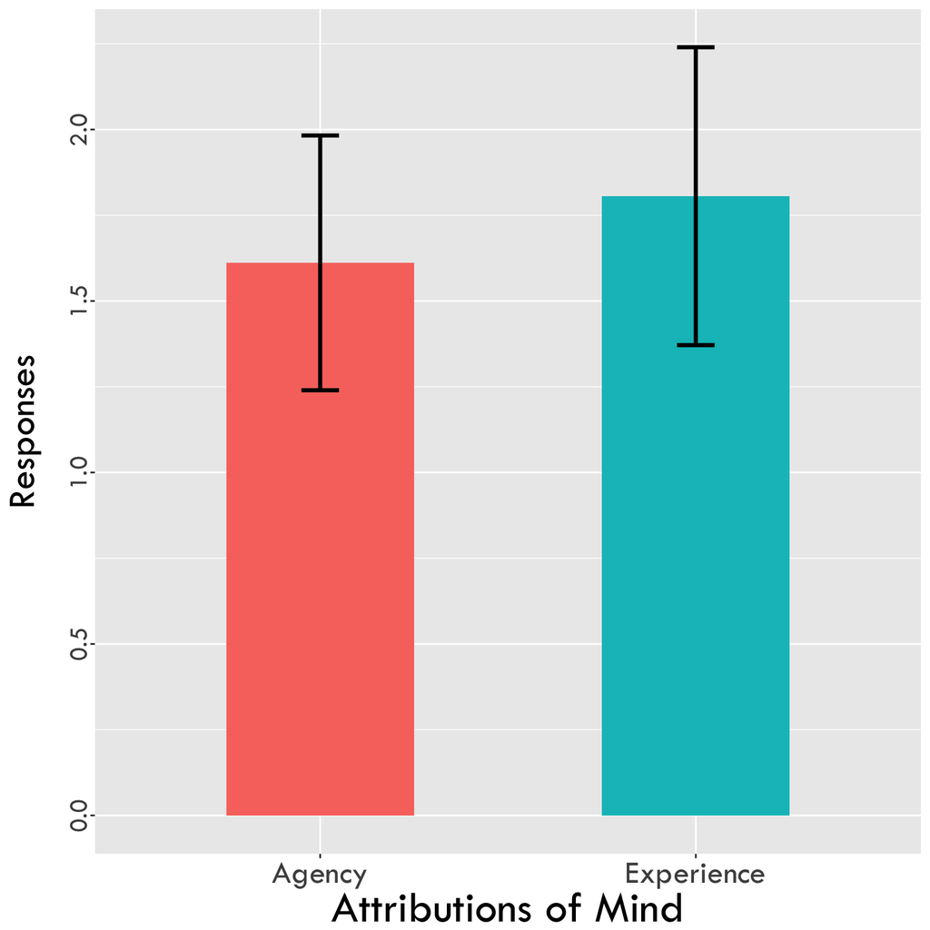